# Studying of Potential Damage from Severe Weather Events

Bruno Martins

08/12/2020

## Synopsis

This project is a study on the severity of climatic events that occurred in the USA. The objective is to show the most dangerous events for human health (deaths due to the type of event) and the economic consequences (mapping material and agricultural damage).

## Data Processing

### 1) Importing data

```r
library(ggplot2)
library(dplyr)
library(tidyr)

url <- "https://d396qusza40orc.cloudfront.net/repdata%2Fdata%2FStormData.csv.bz2"
if (!file.exists("repdata_data_StormData.csv.bz2")){
    download.file(url,"repdata_data_StormData.csv.bz2")
}

data <- read.csv("repdata_data_StormData.csv.bz2")
head(data)
```

### 2) Impact on Population Health

To search for the most dangerous events for the population’s health, I summarized the number of fatalities for each type of event. Below the 8 most dangerous events for people:

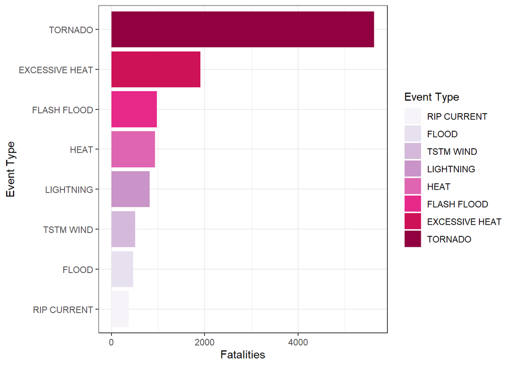

FIG1. Fatalities versus Event Type

```r
data2 <- data %>% group_by(EVTYPE) %>% summarise(FATALITIES = sum(FATALITIES)) %>% arrange(desc(FATALITIES))

g1 <- ggplot(data = head(data2,8), aes(x = reorder(EVTYPE,FATALITIES), y = FATALITIES, fill = reorder(EVTYPE,FATALITIES))) +
    geom_bar(stat="identity")+
    theme_bw() +
    coord_flip() +
    labs(y = "Fatalities", x = "Event Type", fill = "Event Type") +
    scale_fill_brewer(type = "qual", palette="PuRd")
print(g1)
```

### 3) Economic consequences

To examine the economic consequences, I aggregated damage to property and crops for each type of event. After that, I need to rotate the dataset and I created a column called “DMGTY” (Damage type). So I could create a single graphic bar with the proportions of property and agricultural damage.

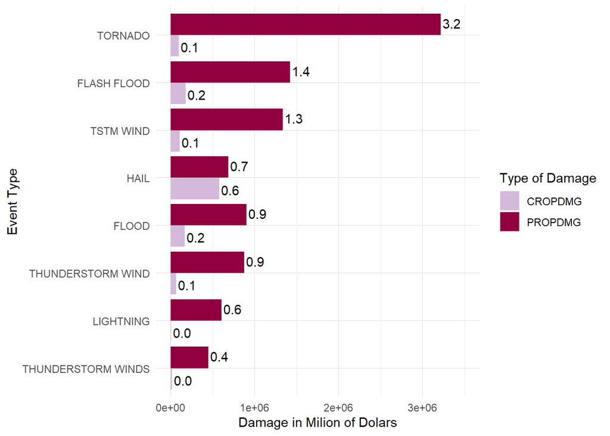

FIG2. Damages versus Event Type

```r
data3 <- data %>% group_by(EVTYPE) %>% summarise(PROPDMG = sum(PROPDMG), CROPDMG = sum(CROPDMG)) %>% arrange(desc(PROPDMG)) %>% pivot_longer(c(PROPDMG,CROPDMG), names_to = "DMGTY", values_to = "TOTALDMG")
data3$DMGTY <- as.factor(data3$DMGTY )

g2 <- ggplot(data = head(data3,16), aes(x = reorder(EVTYPE,TOTALDMG), y = TOTALDMG, fill = DMGTY)) +
    geom_bar(stat="identity",position=position_dodge())+
    theme_minimal() +
    ylim(0, 3500000) +
    labs(y = "Damage in Milion of Dolars", x = "Event Type", fill = "Type of Damage") +
    geom_text(aes(EVTYPE, TOTALDMG,label = sprintf("%2.1f", (TOTALDMG/1e6)), hjust =-.1),
            position = position_dodge(width = 1)) +
    scale_fill_manual(values=c(rgb(212/255,185/255,218/255),rgb(145/255,0,63/255))) +
    coord_flip()
print(g2)
```

## Results

This work showed that Tornado is the most dangerous climatic event both to human health and to economics. For human health, Excessive Heat is the second most dangerous, but with small economic consequence. Analyzing the economic damage, we can see that Hail is the most dangerous for Crop, Tornado and Flash Flood the most dangerous for property.